# Legionnaires’ Disease Outbreaks

Holly Kessler

August 10, 2016

The coordinates of the Legionnairess Disease outbreaks will be used to gather weather data from surrounding stations. The averages of the data will be taken and outputted into a graph containing data from the last 10 years before the outbreak.

First I installed and downloaded the packages needed including rnoaa from github.

```r
library(devtools)
install_github("ropenscilabs/rnoaa")
install_github("ropenscilabs/riem")
```

```r
library(devtools)
library(rnoaa)
library(riem)
library(countyweather)
library(dplyr)
library(plyr)
library(tidyr)
library(weathermetrics)
library(ggplot2)
library(lubridate)
```

I created a data frame including the locations of each outbreak. I found the coordinates at http://maps.cga.harvard.edu/gpf/ and crossed checked them with Google coordinates. The other data in this set are year of outbreak and the year 10 years before the outbreak, onset date, and 14 days before the onset date.

```
##                   id           file_id latitude longitude year_min
## 1           portugal          portugal    38.96     -8.99     2004
## 2         pittsburgh        pittsburgh    40.43    -79.98     2002
## 3             quebec            quebec    46.85    -71.34     2002
## 4     stoke-on-trent    stoke_on_trent    53.02     -2.15     2002
## 5          edinburgh         edinburgh    55.94     -3.20     2002
## 6           miyazaki          miyazaki    31.89    131.34     1992
## 7      pas-de-calais     pas_de_calais    50.51      2.37     1993
## 8           pamplona          pamplona    42.81     -1.65     1996
## 9         rapid city        rapid_city    44.06   -103.22     1995
## 10         sarpsborg         sarpsborg    59.28     11.08     1995
## 11 barrow-in-furness barrow_in_furness    54.10     -3.22     1992
## 12            murcia            murcia    37.98     -1.12     1991
## 13         melbourne         melbourne   -37.86    145.07     1990
## 14      bovenkarspel      bovenkarspel    52.70      5.24     1989
```

[output cut: 27 more lines]

The next function will download information from all of the stations. It only needs to be downloaded once per session. It will take a couple minutes to download

```r
station_data <- ghcnd_stations()[[1]]
```

I created a loop to get a list of the stations within 30 km of the location.

```r
df <- list()
for(i in 1:length(outbreak_loc$id))
  {
    df[i] <- (meteo_nearby_stations(lat_lon_df = outbreak_loc[i,],
                                    station_data = station_data,
                                    var = c("PRCP","TAVG","TMAX","TMIN",
                                            "AWND","MDPR"),
                                    year_min = outbreak_loc[i, "year_min"],
                                    year_max = outbreak_loc[i, "year_max"],
                                    radius = 30))
  }

names(df) <- outbreak_loc$id
stations <- df
stations
```

```
## $portugal
## [1] id        name      latitude  longitude distance
## <0 rows> (or 0-length row.names)
##
## $pittsburgh
##             id                          name latitude longitude  distance
## 1  US1PAAL0014          PA PITTSBURGH 1.6 SW  40.4226  -79.9974  1.687108
## 2  US1PAAL0017           PA WHITEHALL 1.0 SW  40.3475  -80.0022  9.364279
## 3  USW00014762 PA PITTSBURGH ALLEGHENY CO AP  40.3547  -79.9217  9.720301
## 4  US1PAAL0011        PA WEST MIFFLIN 1.3 SW  40.3466  -79.9283 10.255413
## 5  US1PAAL0031      PA SCOTT TOWNSHIP 1.3 NW  40.3978  -80.0967 10.508788
## 6  USC00360861            PA BRADDOCK LOCK 2  40.3917  -79.8594 11.063215
## 7  US1PAAL0009                 PA PATHFINDER  40.3416  -80.0485 11.414110
## 8  USC00362574      PA EMSWORTH L/D OHIO RVR  40.5019  -80.0833 11.844197
## 9  US1PAAL0016            PA GLENSHAW 1.3 NW  40.5488  -79.9800 13.209957
```

[output cut: 429 more lines]

Not all the locations have stations nearby. Therefore, I will omit them from the weather data evaluation using the following code.

```r
has_stations <- sapply(stations, function(x) nrow(x) > 0)
outbreak_loc$stations <- paste0(outbreak_loc$stations, has_stations)
outbreak_loc_true <- outbreak_loc[ !grepl("FALSE", outbreak_loc$stations) , ]
outbreak_loc_true$stations <- NULL
outbreak_loc_true
```

```
##              id      file_id latitude longitude year_min   date_min
## 2    pittsburgh   pittsburgh    40.43    -79.98     2002 2002-01-01
## 3        quebec       quebec    46.85    -71.34     2002 2002-01-01
## 6      miyazaki     miyazaki    31.89    131.34     1992 1992-01-01
## 8      pamplona     pamplona    42.81     -1.65     1996 1996-01-01
## 9    rapid city   rapid_city    44.06   -103.22     1995 1995-01-01
## 10    sarpsborg    sarpsborg    59.28     11.08     1995 1995-01-01
## 12       murcia       murcia    37.98     -1.12     1991 1991-01-01
## 13    melbourne    melbourne   -37.86    145.07     1990 1990-01-01
## 14 bovenkarspel bovenkarspel    52.70      5.24     1989 1989-01-01
## 15       london       london    51.52     -0.10     1979 1979-01-01
## 16       sydney       sydney   -33.85    150.93     2006 2006-01-01
## 17     genesee1     genesee1    43.09    -83.63     2004 2004-01-01
## 18     genesee2     genesee2    43.09    -83.63     2005 2005-01-01
## 19     columbus     columbus    39.98    -82.99     2003 2003-01-01
```

[output cut: 17 more lines]

Using the countyweather codes I can gather the data for each station in a loop. The code gathers the weather data for each stations and averages them. Then I saved all the data as rds. files because they take a long time to gather. The data is saved in a folder I created called “weather_files/”

```r
for(i in which(has_stations))
{
    meteo_df <- meteo_pull_monitors(monitors = stations[[i]]$id,
                                 keep_flags = FALSE,
                                 date_min = outbreak_loc$date_min[i],
                                 date_max = outbreak_loc$date_max[i],
                                 var = c("prcp","snow","snwd","tmax","tmin","tavg"))

   coverage_df <- rnoaa::meteo_coverage(meteo_df, verbose = FALSE)
   filtered <- countyweather:::filter_coverage(coverage_df, 0.90)
   good_monitors <- unique(filtered$id)
   filtered_data <- dplyr::filter(meteo_df, id %in% good_monitors)
   averaged <- countyweather:::ave_weather(filtered_data)
   file_name <- paste0("weather_files/", outbreak_loc$file_id[i], ".rds")
   saveRDS(averaged, file_name)
   #readRDS(file_name)
  }
```

Now that all of the data is gathered and averaged I can plot the data. The loop will go through the files in order which is in alphabetical order. Therefore I must order my outbreak data frame into alphabetical order too. I will rename this data frame as df_stations for plotting.

```
##              id      file_id latitude longitude year_min   date_min
## 1  bovenkarspel bovenkarspel    52.70      5.24     1989 1989-01-01
## 2         bronx        bronx    40.82    -73.92     2005 2005-01-01
## 3      columbus     columbus    39.98    -82.99     2003 2003-01-01
## 4      genesee1     genesee1    43.09    -83.63     2004 2004-01-01
## 5      genesee2     genesee2    43.09    -83.63     2005 2005-01-01
## 6        london       london    51.52     -0.10     1979 1979-01-01
## 7     melbourne    melbourne   -37.86    145.07     1990 1990-01-01
## 8      miyazaki     miyazaki    31.89    131.34     1992 1992-01-01
## 9        murcia       murcia    37.98     -1.12     1991 1991-01-01
## 10     pamplona     pamplona    42.81     -1.65     1996 1996-01-01
## 11   pittsburgh   pittsburgh    40.43    -79.98     2002 2002-01-01
## 12       quebec       quebec    46.85    -71.34     2002 2002-01-01
## 13   rapid city   rapid_city    44.06   -103.22     1995 1995-01-01
## 14    sarpsborg    sarpsborg    59.28     11.08     1995 1995-01-01
```

[output cut: 17 more lines]

# PLOT 1

## Outbreak Distribution

This plot is divided by outbreaks in the northern and southern hemisphere. This allows us to see when the outbreaks generally occur in the year.

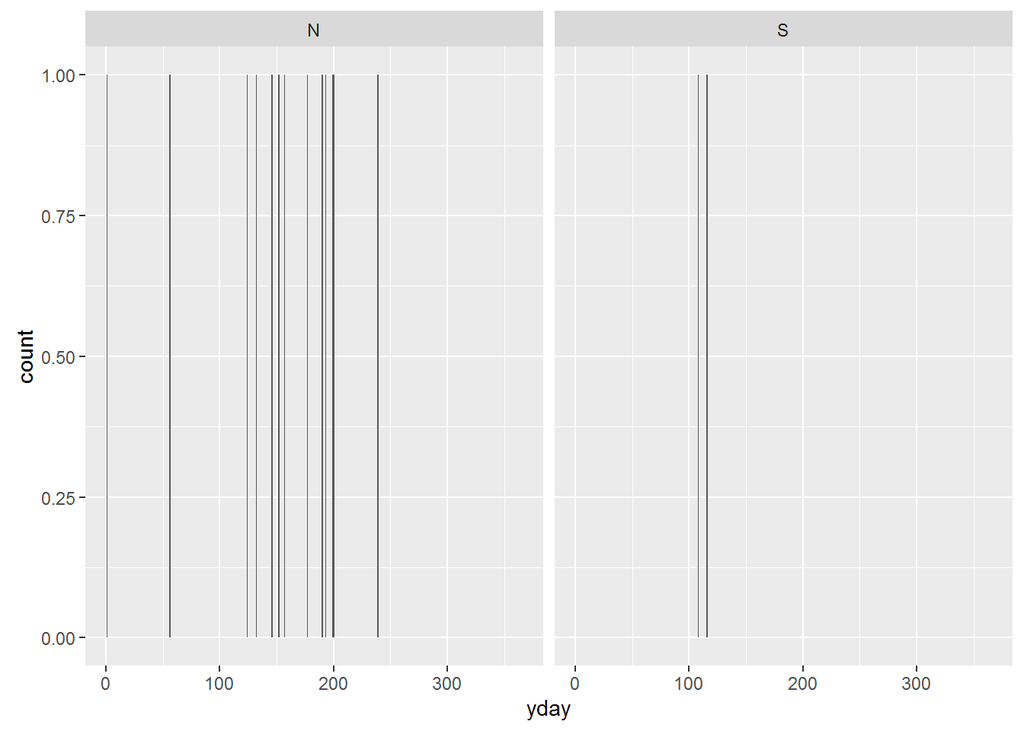

# PLOT 2

## 10 years for all data

These plots allow for a quick glance into all the weather variables for each location.

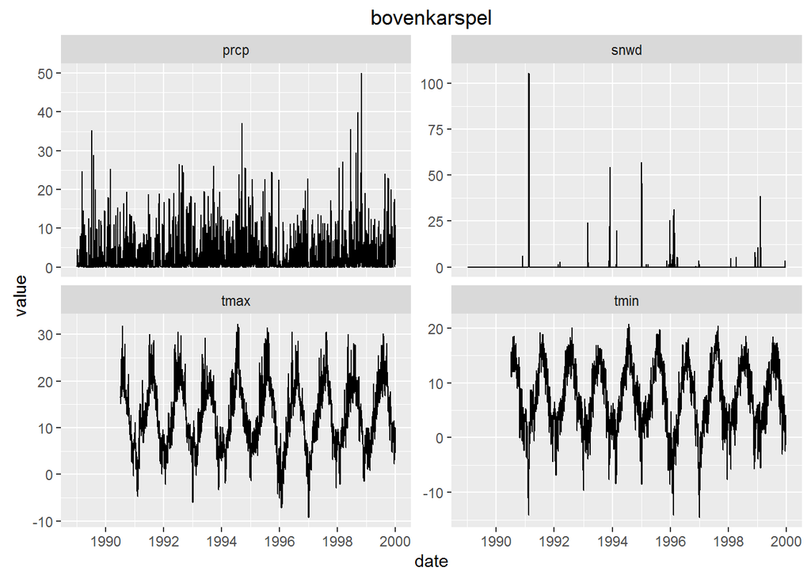

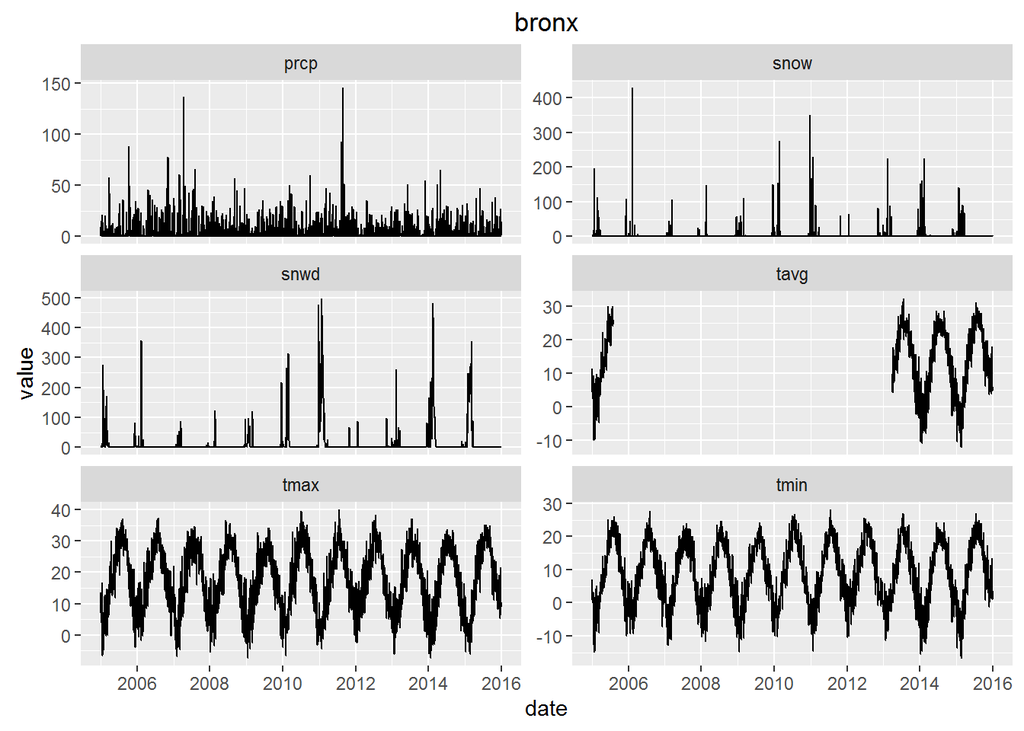

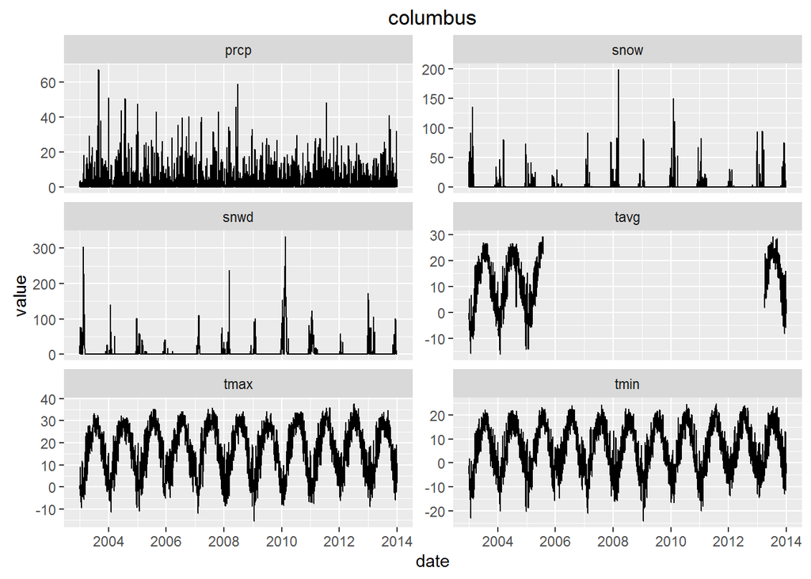

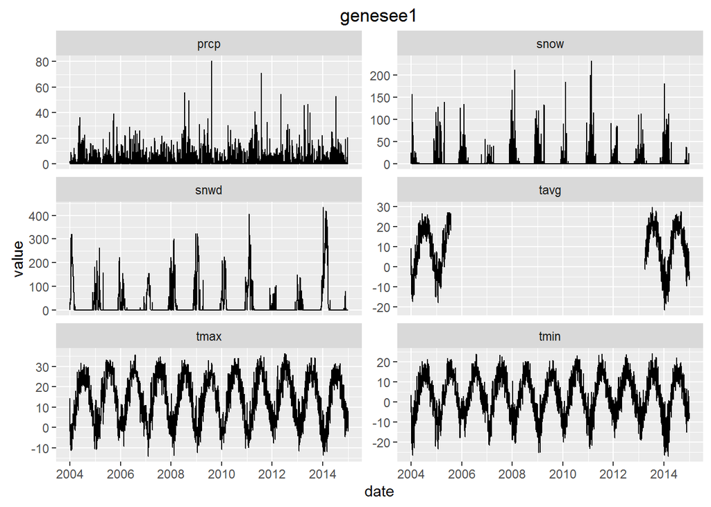

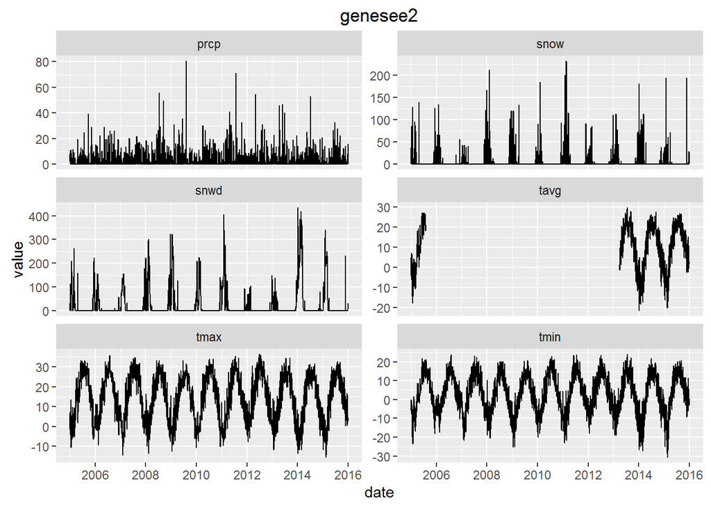

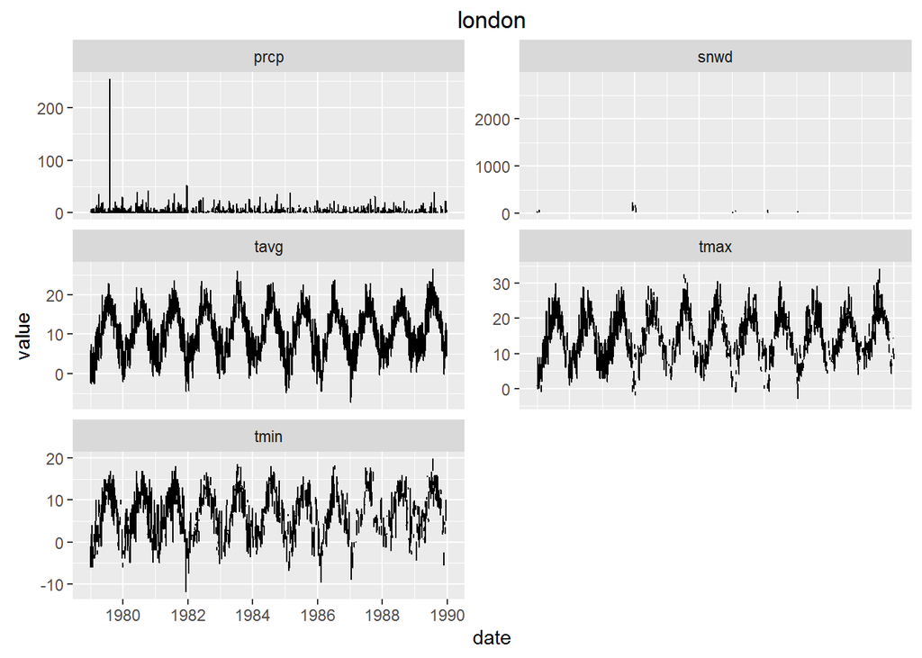

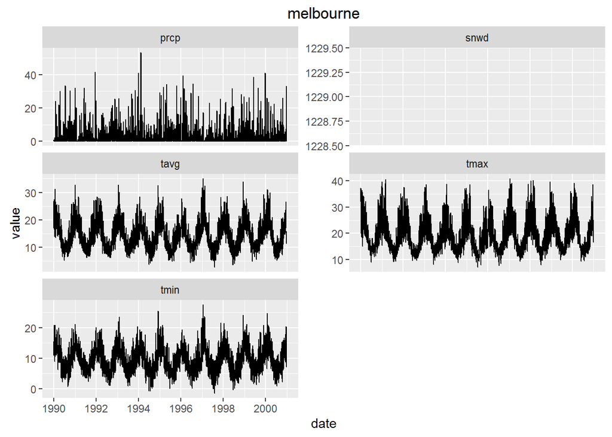

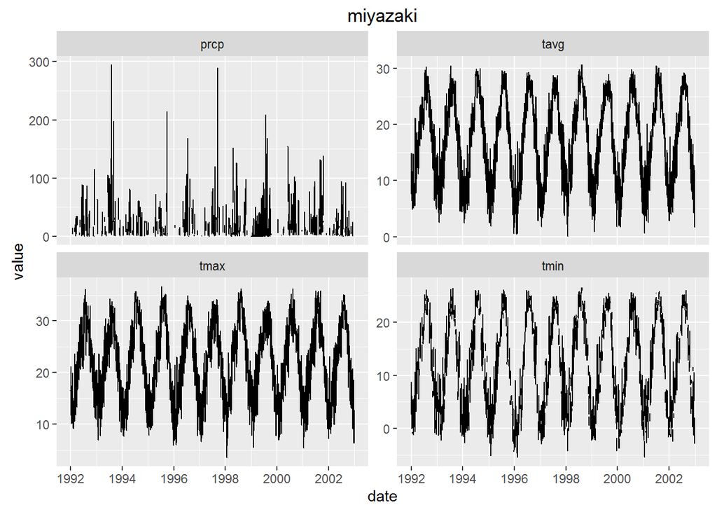

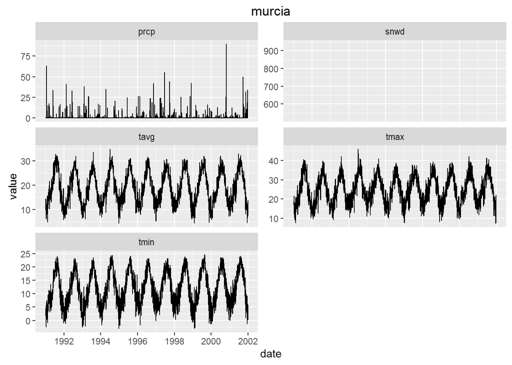

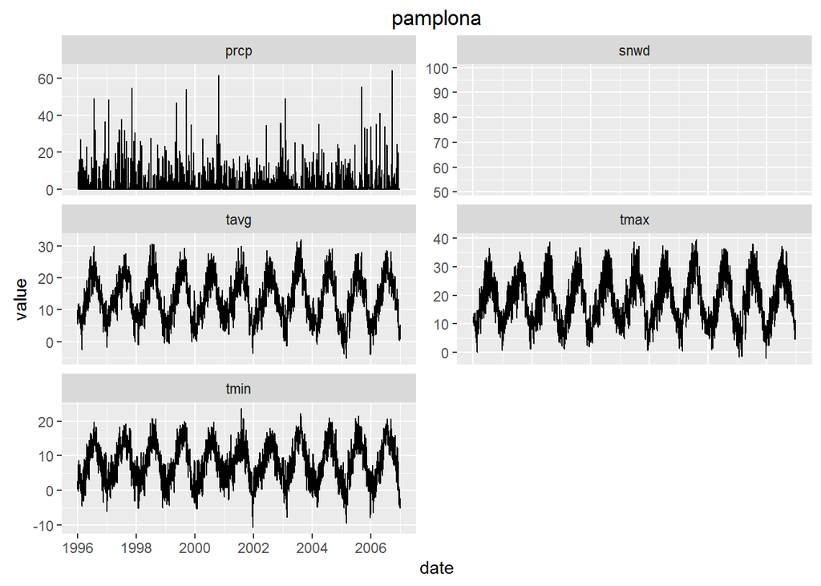

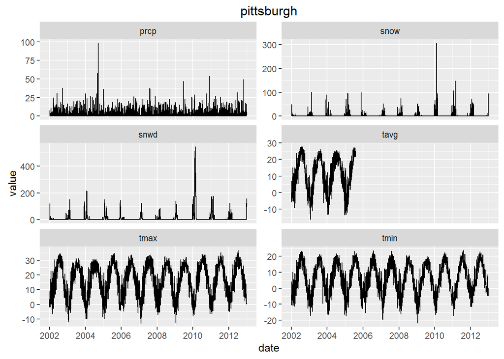

[figure not shown]

[4 more figures not shown]

# PLOT 3

## TMAX and TMIN

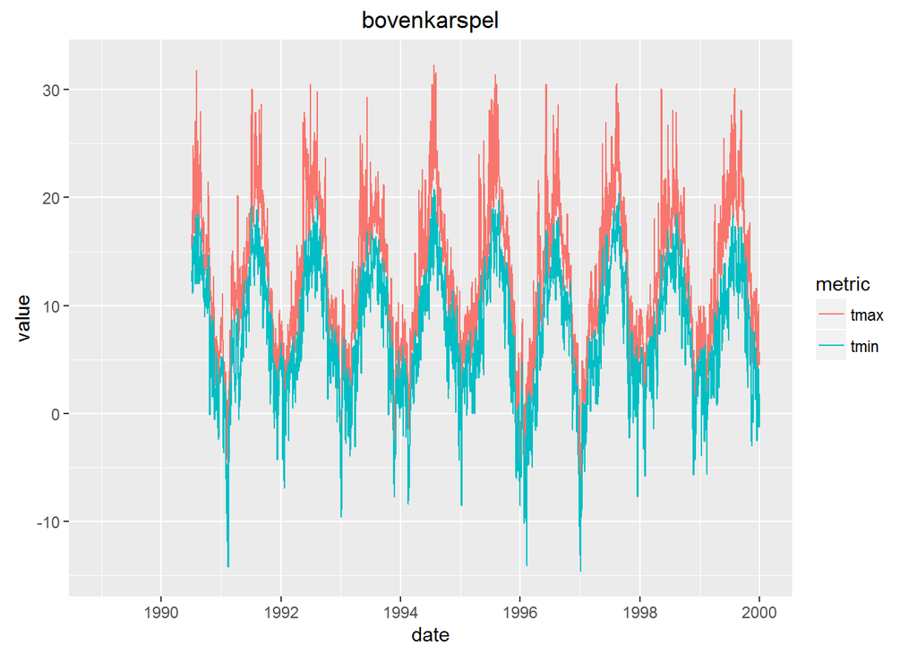

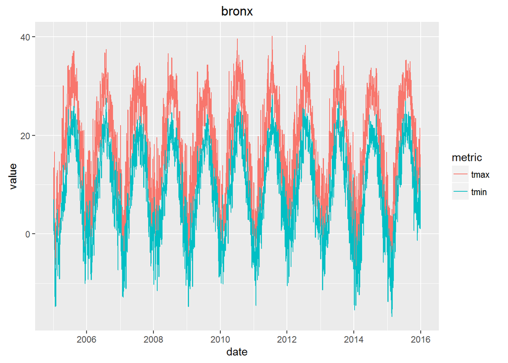

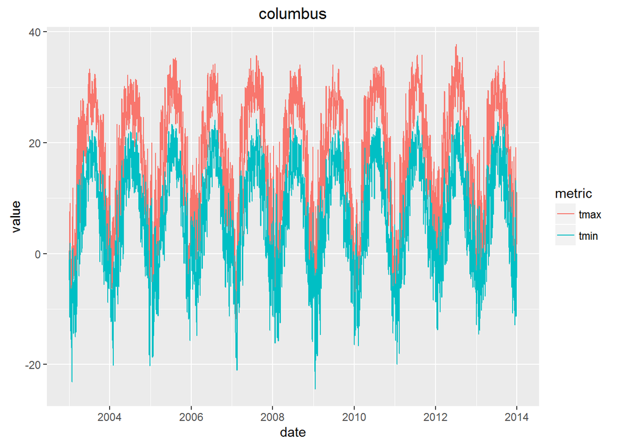

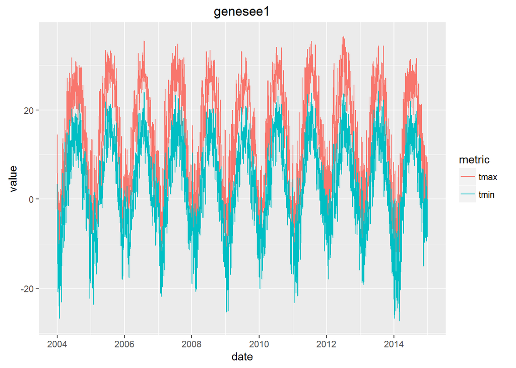

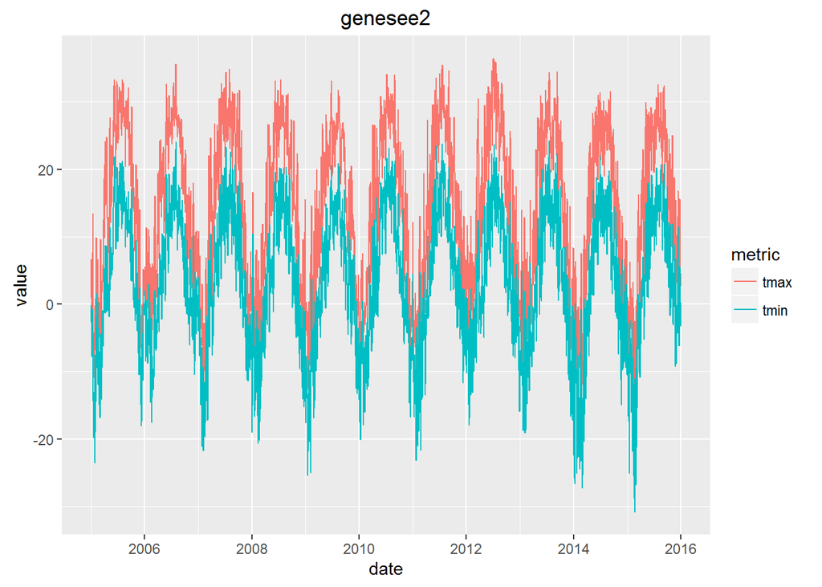

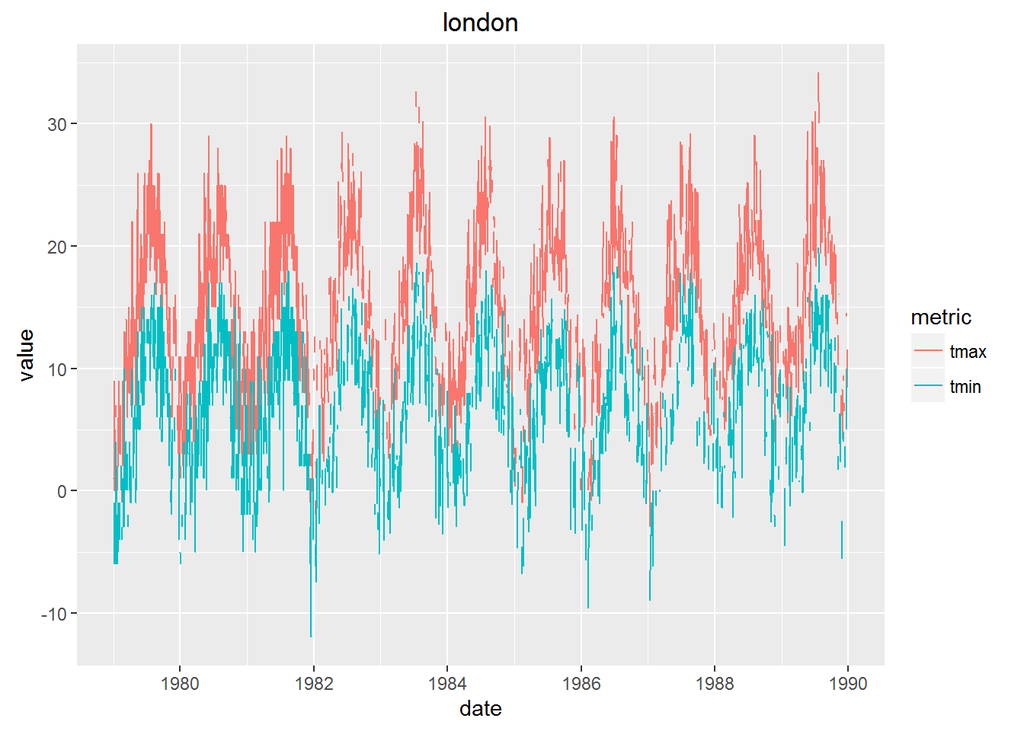

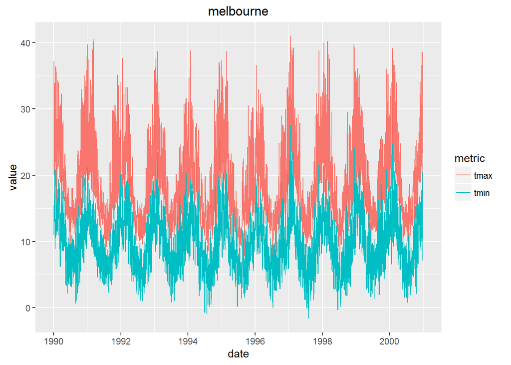

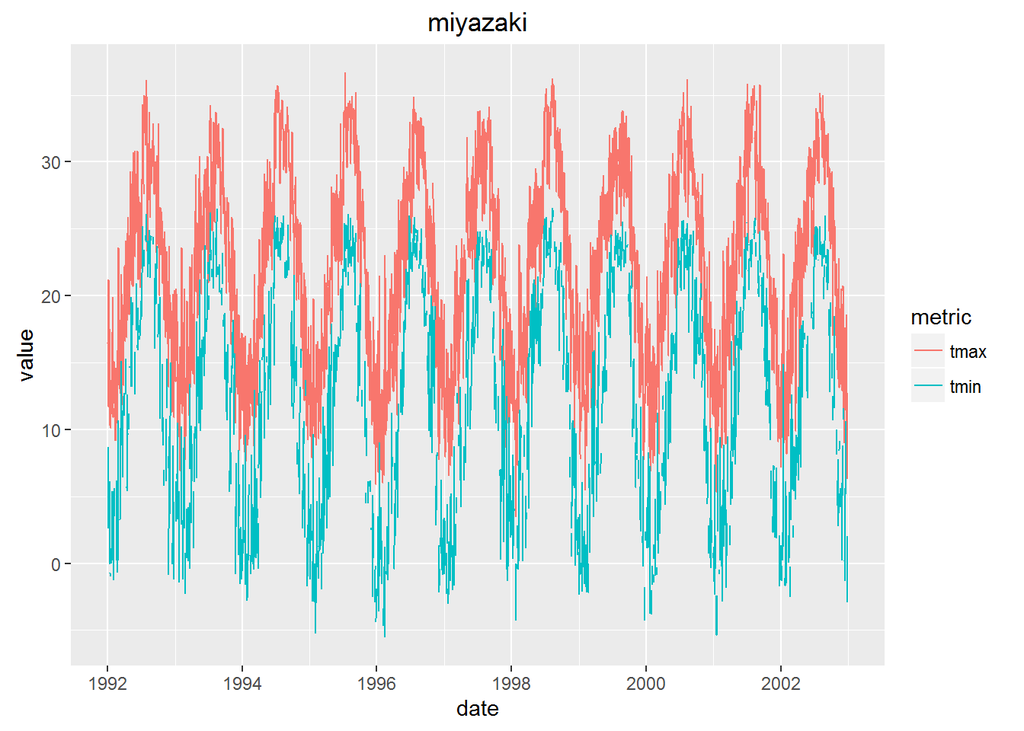

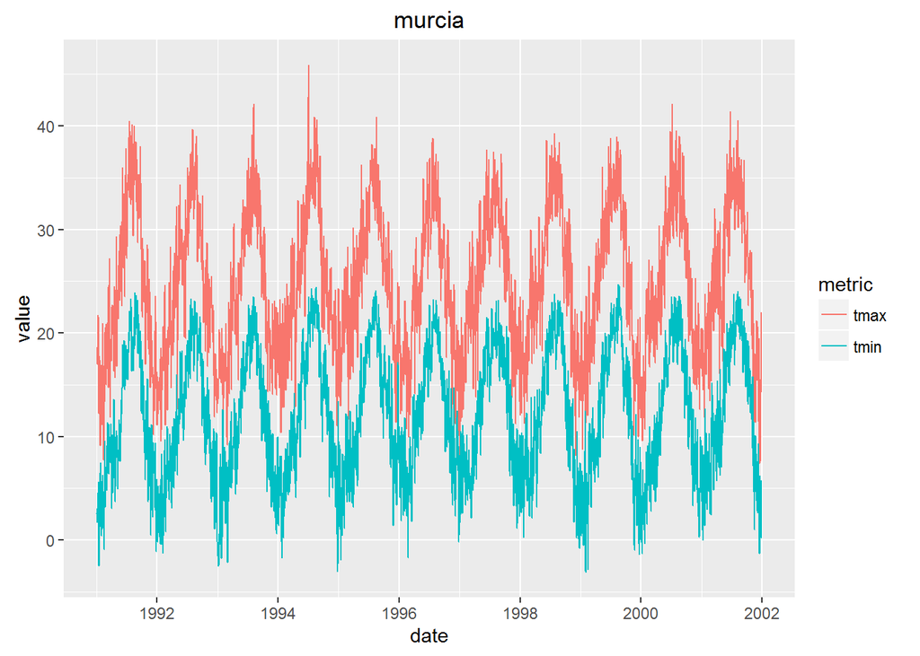

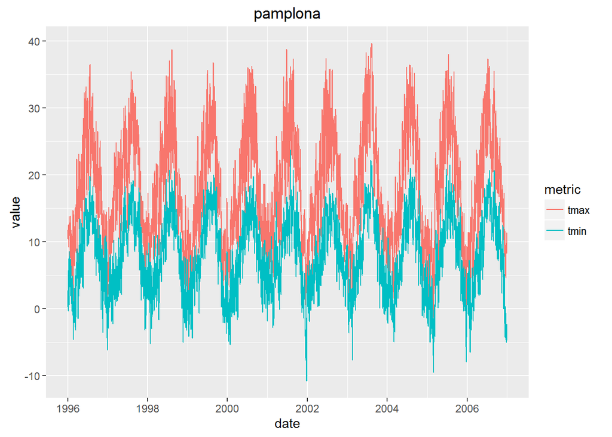

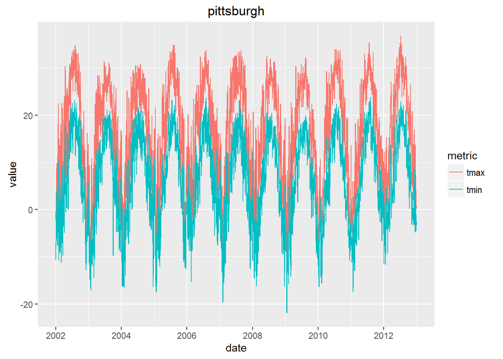

[figure not shown]

[4 more figures not shown]

# PLOT 4

## Precipitation

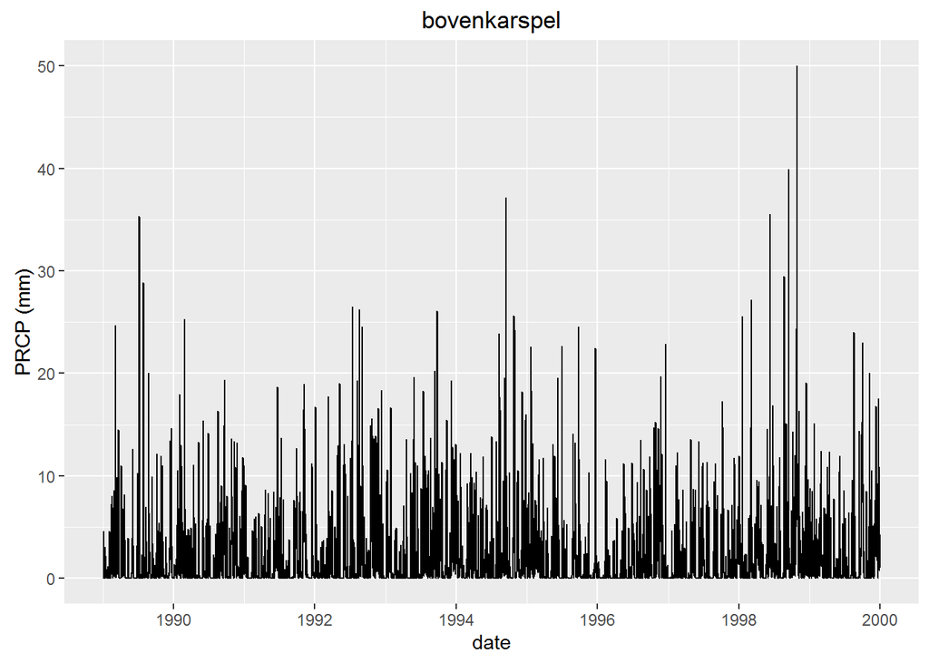

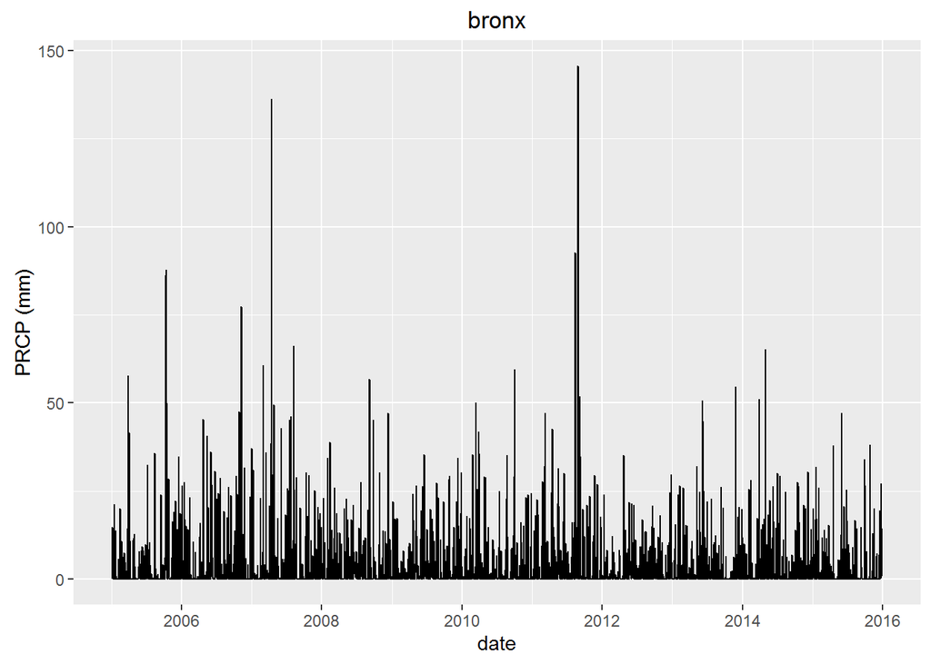

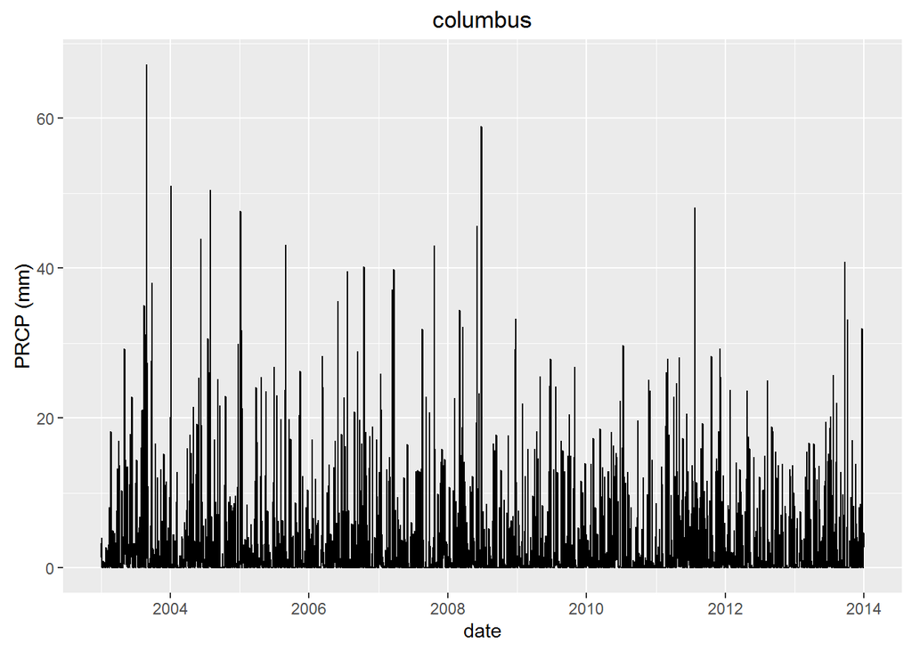

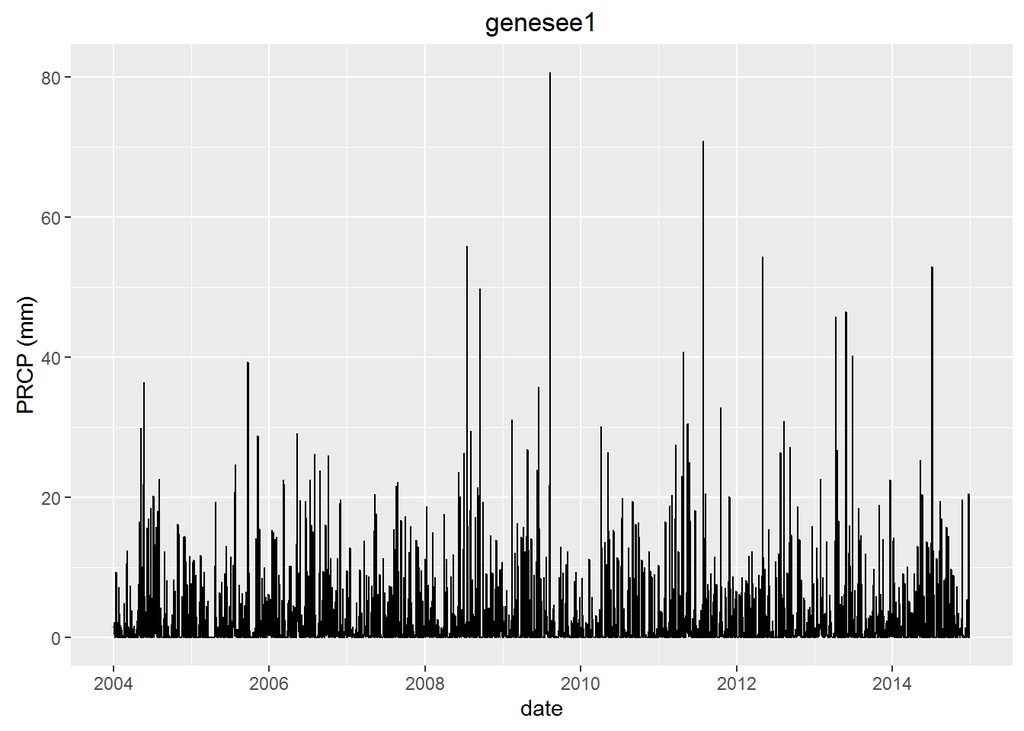